# How Does PTSD Hypervigilance Impact Event Segmentation?

2024-12-08

## Research Questions

### Big Question:

How does PTSD influence the way individuals perceive and segment everyday activities into meaningful events?

### Little Question:

How do individual PTSD participants’ mean segmentation agreement scores vary across a movie, and what patterns of clustering or dispersion emerge in their performance?

## Data Source :

### Sources:

- **Study**:
- Post-traumatic Stress and the Comprehension of Everyday Activity by Michelle L. Eisenberg, Jesse Q. Sargent, and Jeffrey M. Zacks.
- **Participants**:
- 137 individuals, aged 21–79, with varying PTSD symptom severity.
- 51% female; 72% White; mean age = 50 years.
- Participants were recruited immediately after their participation in a cross-sectional study of the relationship between age, cognitive ability, and event segmentation.

## Tasks/Methods:

- Reciting recollection of events after viewing them in a movie (for 3 Movies).
- PTSD severity was measured using the Traumatic Life Events Questionnaire(TLEQ).
- Button-press segmentation of coarse and fine-grained events(pressing when the beginning and end of “large” or “small” events occur) while viewing visual stimuli(3 Movies).
  - Each participant’s segmentation (coarse and fine) was compared to the group’s overall segmentation using correlations.
  - These correlations were scaled to a 0–1 range, with 1 representing maximum agreement and 0 representing no agreement.
  - Finally, the coarse and fine segmentation scores were averaged to get a final segmentation agreement score for each participant.

## Segmentation Agreement for First Movie: Coarse and Fine Events

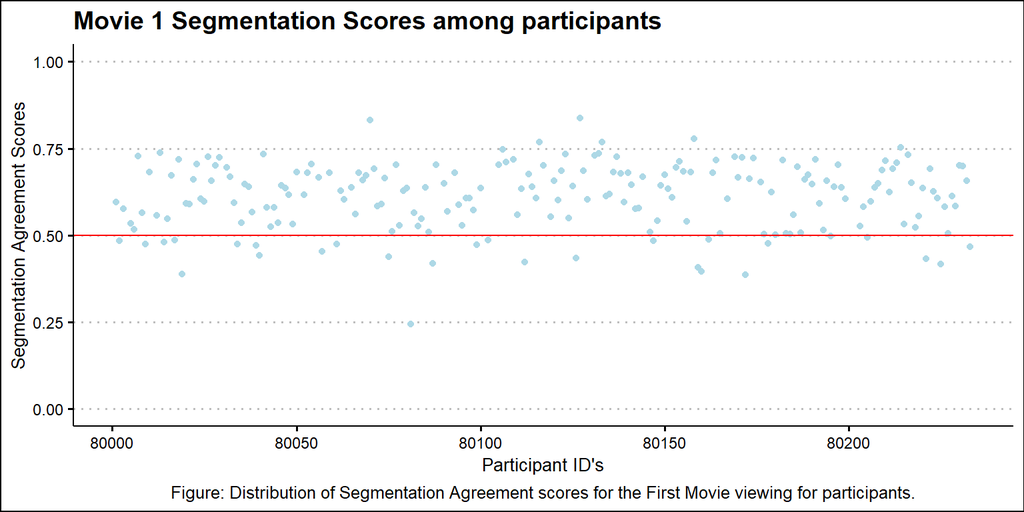